# Project Deliverable - Final

## Exploring Our Data

```python
# Libraries needed for this deliverable
import numpy as np
import pandas as pd

import matplotlib.pyplot as plt
from matplotlib.pyplot import subplots
%matplotlib inline

import seaborn as sns
import plotly.express as px
sns.set()

from sklearn.tree import DecisionTreeRegressor  # for running the regressive model
from sklearn.tree import export_graphviz # Used for plotting resulting trees
from sklearn.tree import plot_tree # Used for plotting resulting trees
from sklearn import tree
from sklearn.model_selection import train_test_split, GridSearchCV, KFold, cross_val_score
from sklearn.linear_model import LinearRegression, Lasso
from sklearn.ensemble import RandomForestRegressor, GradientBoostingRegressor
from sklearn.metrics import root_mean_squared_error, r2_score, mean_squared_error, mean_absolute_error
from sklearn.preprocessing import StandardScaler, OneHotEncoder
from sklearn.pipeline import Pipeline
from sklearn.compose import ColumnTransformer
from sklearn.impute import SimpleImputer
from sklearn.svm import SVR
import sklearn.metrics as metrics
from sklearn.metrics import (
    f1_score,
    accuracy_score,
    recall_score,
    precision_score,
    confusion_matrix,
    roc_auc_score,
    precision_recall_curve,
    confusion_matrix,
    classification_report,
    roc_curve,)

from pygam import LinearGAM, s

import warnings
warnings.simplefilter('ignore')

import statsmodels.api as sm
from statsmodels.stats.outliers_influence import variance_inflation_factor as VIF
from statsmodels.stats.anova import anova_lm
from scipy import stats

from ISLP import load_data
from ISLP.models import (ModelSpec as MS,summarize,poly)
# Removes the limit for the number of displayed columns
pd.set_option("display.max_columns", None)
# Sets the limit for the number of displayed rows
pd.set_option("display.max_rows", 200)


# import modules and tools as a classes from Tensorflow for constructing the NN
import tensorflow as tf
from tensorflow.keras.models import Sequential
from tensorflow.keras.layers import Dense, Dropout, Activation

# Other modlues and classes
import random
from tensorflow.keras import backend


#load the dataset
database = pd.read_excel('/Users/lisad98/Downloads/ONLINE_CLIENTS_SV.xlsx', sheet_name='DB')

#showing top 5 rows
database.head()
```

|  | CLIENT_ID | CUMMSALES_LAST12WEEKS | FREQUENCY_LAST12WEEKS | AVERAGE_TICKET | RECENCY | CONSISTENCY | BRANCH | SEGMENT_1 | LOYALTY_GROUP | PRICE_GROUP | SEGMENT_2 | GENDER | MARITAL_STATUS | BIRTH_DATE | AGE | MOSTUSED_PLATFORM |
| --- | --- | --- | --- | --- | --- | --- | --- | --- | --- | --- | --- | --- | --- | --- | --- | --- |
| 0 | 22335 | 7516.36 | 10 | 751.64 | 11 | 8 | 2979 | Core | Vip | Very Price Sensitive | B | Female | Married | 1973-11-12 | 44.57 | Mobile |
| 1 | 22349 | 860.53 | 1 | 860.53 | 49 | 1 | 2979 | Core | Ocasional | Selective Price Sensitive | B | Female | Married | 1988-04-24 | 30.11 | Web |
| 2 | 22389 | 1576.32 | 2 | 788.16 | 74 | 1 | 2979 | Core | Ocasional | Very Price Sensitive | B | Female | Married | 1977-01-15 | 41.39 | Mobile |
| 3 | 22679 | 4531.18 | 3 | 1510.39 | 24 | 2 | 2961 | Core | Ocasional | Moderately Price Sensitive | B | Male | Married | 1987-05-20 | 31.04 | Mobile |
| 4 | 22878 | 6193.58 | 1 | 6193.58 | 70 | 1 | 2979 | Core | Ocasional | Selective Price Sensitive | B | Male | Married | 1968-09-07 | 49.75 | Web |

```python
#Dataset type
database.info()
```

```
<class 'pandas.core.frame.DataFrame'>
RangeIndex: 9504 entries, 0 to 9503
Data columns (total 16 columns):
 #   Column                 Non-Null Count  Dtype
---  ------                 --------------  -----
 0   CLIENT_ID              9504 non-null   int64
 1   CUMMSALES_LAST12WEEKS  9504 non-null   float64
 2   FREQUENCY_LAST12WEEKS  9504 non-null   int64
 3   AVERAGE_TICKET         9504 non-null   float64
 4   RECENCY                9504 non-null   int64
 5   CONSISTENCY            9504 non-null   int64
 6   BRANCH                 9504 non-null   int64
 7   SEGMENT_1              9504 non-null   object
 8   LOYALTY_GROUP          9504 non-null   object
 9   PRICE_GROUP            9504 non-null   object
 10  SEGMENT_2              9504 non-null   object
 11  GENDER                 9503 non-null   object
 12  MARITAL_STATUS         9503 non-null   object
 13  BIRTH_DATE             8346 non-null   datetime64[ns]
 14  AGE                    8346 non-null   float64
 15  MOSTUSED_PLATFORM      9504 non-null   object
dtypes: datetime64[ns](1), float64(3), int64(5), object(7)
memory usage: 1.2+ MB
```

```python
#Dataset dimensions
print("There are", database.shape[0], 'rows and', database.shape[1], "columns.")
```

```
There are 9504 rows and 16 columns.
```

```python
#Check for missing values
database.isnull().sum()
```

```
CLIENT_ID                   0
CUMMSALES_LAST12WEEKS       0
FREQUENCY_LAST12WEEKS       0
AVERAGE_TICKET              0
RECENCY                     0
CONSISTENCY                 0
BRANCH                      0
SEGMENT_1                   0
LOYALTY_GROUP               0
PRICE_GROUP                 0
SEGMENT_2                   0
GENDER                      1
MARITAL_STATUS              1
BIRTH_DATE               1158
AGE                      1158
MOSTUSED_PLATFORM           0
dtype: int64
```

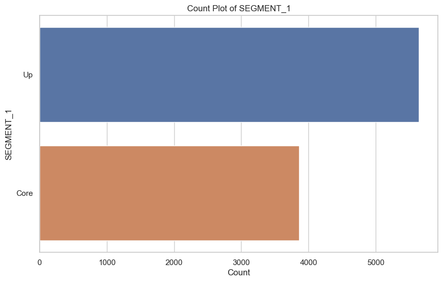

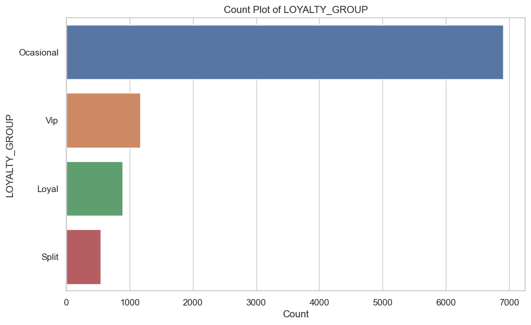

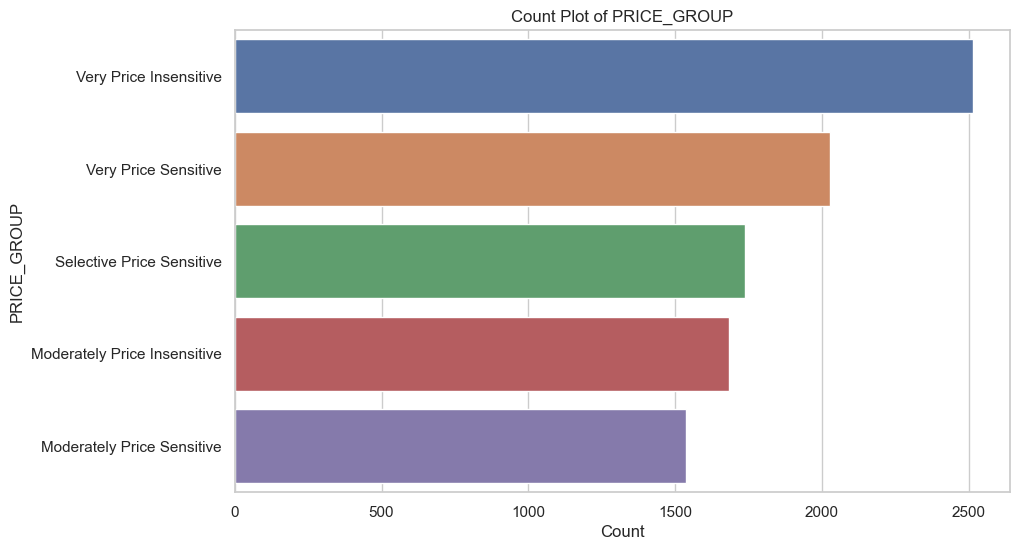

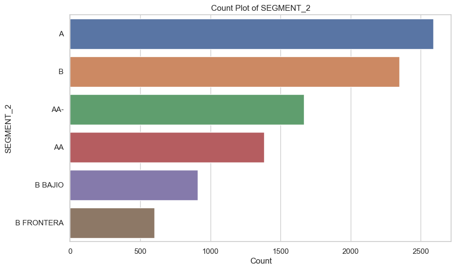

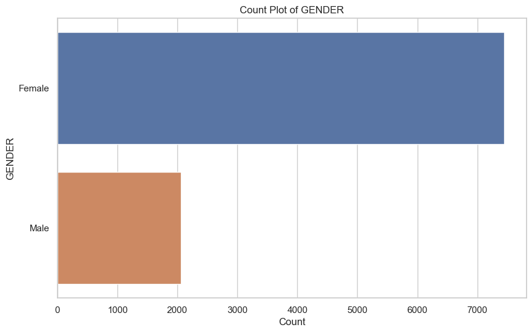

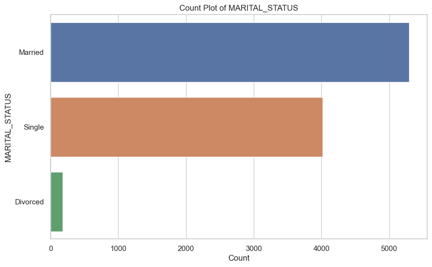

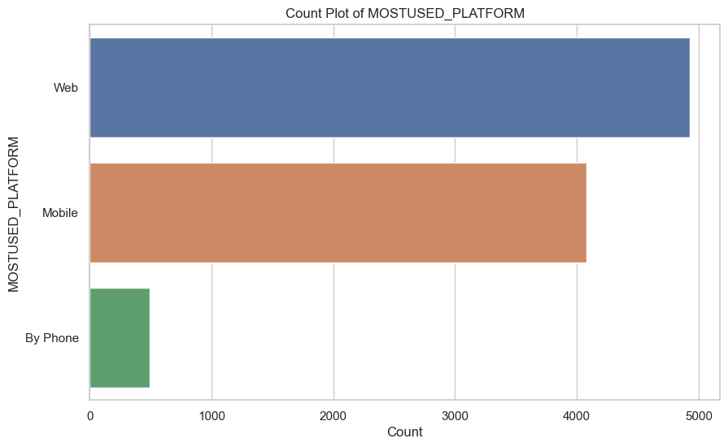

```python
#visualize categorical data
def visualize_categorical_variables(database, max_categories=20):
    """
    Automatically visualize all non-numerical (categorical) variables in a DataFrame.
    Generates count plots for each categorical variable with a reasonable number of unique values.

    Parameters:
    - df: pandas DataFrame containing the data to be visualized.
    - max_categories: Maximum number of unique categories to visualize for each variable.
                      Variables with more categories than this will be skipped to avoid cluttered plots.
    """
    # Identify categorical columns
    categorical_columns = database.select_dtypes(include=['object', 'category', 'bool']).columns

    sns.set_style("whitegrid")

    for col in categorical_columns:
        if database[col].nunique() > max_categories:
            print(f'Skipping {col} as it has more than {max_categories} unique categories.')
            continue

        plt.figure(figsize=(10, 6))
        sns.countplot(y=col, data=database, order = database[col].value_counts().index)
        plt.title(f'Count Plot of {col}')
        plt.xlabel('Count')
        plt.ylabel(col)
        plt.show()

visualize_categorical_variables(database, max_categories=20)
```

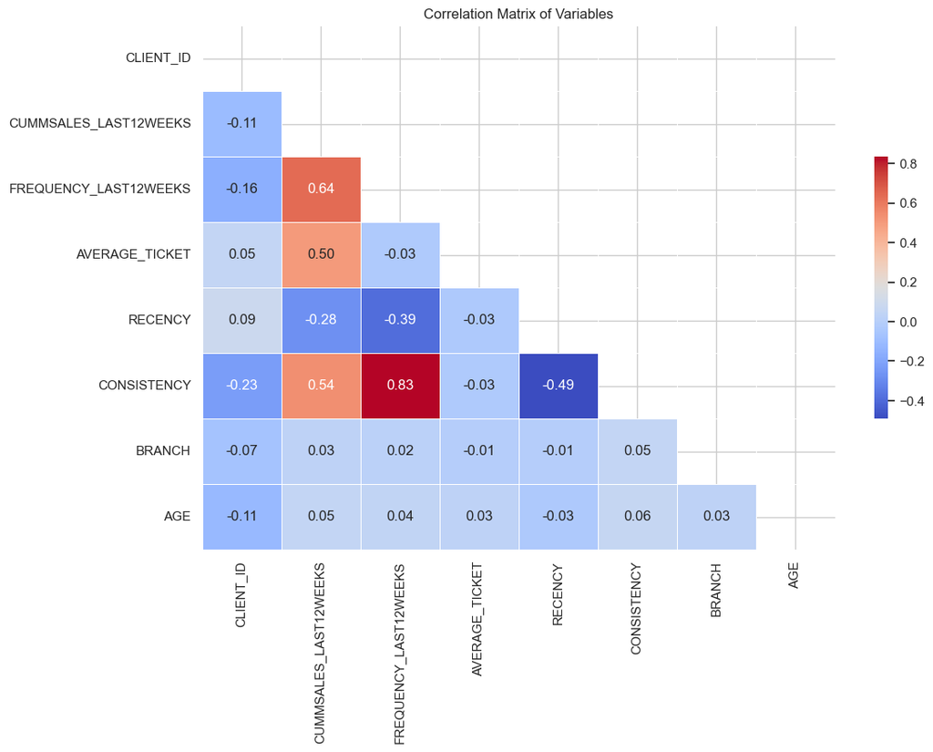

```python
# Correlation matrix to understand relationships
correlation_matrix = database.corr(numeric_only=True)
mask = np.triu(np.ones_like(correlation_matrix, dtype=bool))
plt.figure(figsize=(12, 8))
sns.heatmap(correlation_matrix, mask=mask, annot=True, cmap='coolwarm', fmt=".2f",
            linewidths=.5, cbar_kws={"shrink": .5})
plt.title('Correlation Matrix of Variables')
plt.show()
```

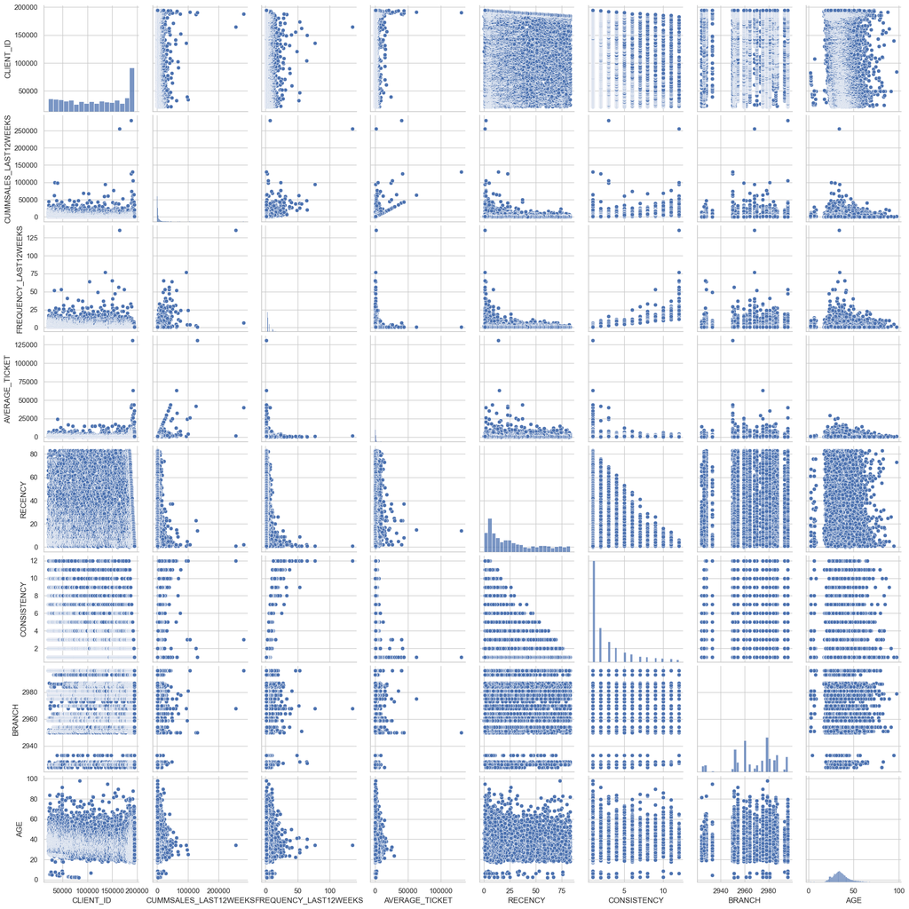

```python
sns.pairplot(data=database)
```

### **Understanding the Data**

Showing these graphs, we can see the different relationships between the variables. With CLIENT_ID being an identifier, I decided to drop this variable because it has nothing to do with the data itself. The BRANCH variable has too many values for me to include in the predictors.

When looking at the correlation matrix, specifically the CUMMSALES_LAST12WEEKS, we can see that FREQUENCY_LAST12WEEKS, AVERAGE_TICKET, and CONSISTENCY all have a strong correlation with the outcome variable, therefore we will include those in our predictors.

### **Outliers**

We can seem from these graphs that there are a few extreme outliers in cummulative sales, frequency, and average ticket. I chose to keep these outliers in the dataset because even though they are extreme, I still believe them to be true data points just by the kind of variables they are.

```python
# List of columns to include in the new DataFrame 'db'
columns_to_include = [
    'CUMMSALES_LAST12WEEKS', 'FREQUENCY_LAST12WEEKS', 'AVERAGE_TICKET',
    'CONSISTENCY', 'LOYALTY_GROUP', 'MOSTUSED_PLATFORM']

# Create the new DataFrame 'db' with only the selected columns
data = database[columns_to_include].copy()

data.head()
```

|  | CUMMSALES_LAST12WEEKS | FREQUENCY_LAST12WEEKS | AVERAGE_TICKET | CONSISTENCY | LOYALTY_GROUP | MOSTUSED_PLATFORM |
| --- | --- | --- | --- | --- | --- | --- |
| 0 | 7516.36 | 10 | 751.64 | 8 | Vip | Mobile |
| 1 | 860.53 | 1 | 860.53 | 1 | Ocasional | Web |
| 2 | 1576.32 | 2 | 788.16 | 1 | Ocasional | Mobile |
| 3 | 4531.18 | 3 | 1510.39 | 2 | Ocasional | Mobile |
| 4 | 6193.58 | 1 | 6193.58 | 1 | Ocasional | Web |

```python
def histogram_boxplot(data, feature, figsize=(12, 7), kde=True, bins=None):
    """
    Boxplot and histogram combined

    data: dataframe
    feature: dataframe column
    figsize: size of figure (default (12,7))
    kde: whether to the show density curve (default False)
    bins: number of bins for histogram (default None)
    """
    f2, (ax_box2, ax_hist2) = plt.subplots(
        nrows=2,  # Number of rows of the subplot grid= 2
        sharex=True,  # x-axis will be shared among all subplots
        gridspec_kw={"height_ratios": (0.25, 0.75)},
        figsize=figsize,
    )  # creating the 2 subplots
    sns.boxplot(
        data=data, x=feature, ax=ax_box2, showmeans=True, color="violet"
    )  # boxplot will be created and a star will indicate the mean value of the column
    sns.histplot(
        data=data, x=feature, kde=kde, ax=ax_hist2, bins=bins, palette="winter"
    ) if bins else sns.histplot(
        data=data, x=feature, kde=kde, ax=ax_hist2
    )  # For histogram
    ax_hist2.axvline(
        data[feature].mean(), color="green", linestyle="--"
    )  # Add mean to the histogram
    ax_hist2.axvline(
        data[feature].median(), color="black", linestyle="-"
    )  # Add median to the histogram
```

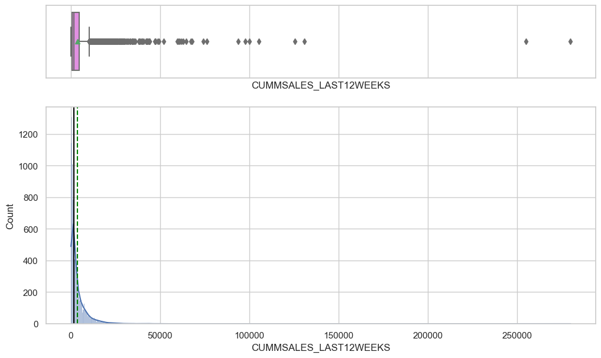

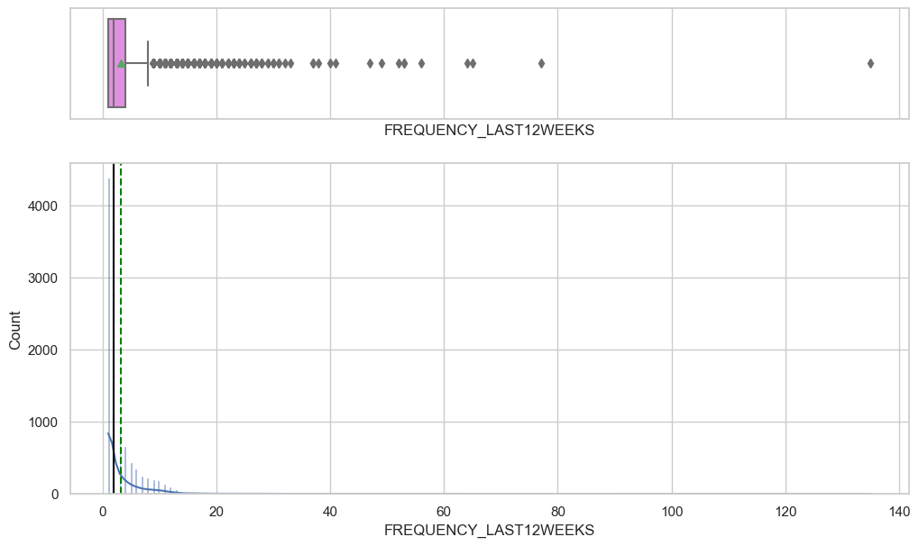

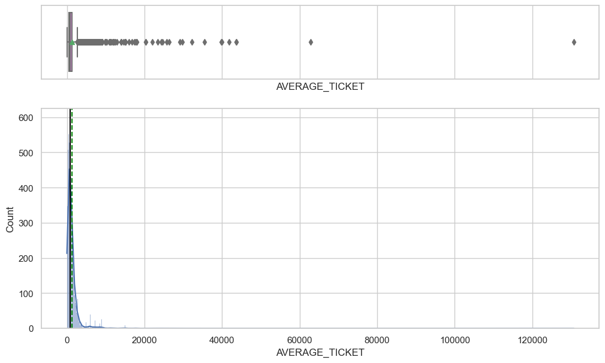

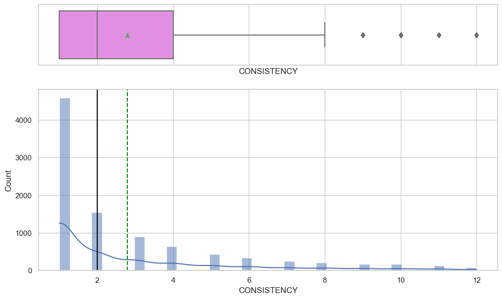

```python
#checking for outliers
numerical_columns = data.select_dtypes(include='number').columns

for column in numerical_columns:
    histogram_boxplot(data, column)
    plt.show()
```

```python
# Create the set in independent variables and the dependent variable
X = data.drop(["CUMMSALES_LAST12WEEKS"], axis=1)
y = data["CUMMSALES_LAST12WEEKS"]

#Dividing into training set and test set
X_train, X_test, y_train, y_test = train_test_split(X, y, test_size=0.2, random_state=1234)
```

```python
numerical_cols = X_train.select_dtypes(include=['int64', 'float64']).columns
categorical_cols = X_train.select_dtypes(include=['object', 'category']).columns
```

```python
numerical_imputer = SimpleImputer(strategy='median')
X_train_num = numerical_imputer.fit_transform(X_train[numerical_cols])
X_test_num = numerical_imputer.transform(X_test[numerical_cols])

scaler = StandardScaler()
X_train_num_scaled = scaler.fit_transform(X_train_num)
X_test_num_scaled = scaler.transform(X_test_num)
```

## **One-Hot Encoding**

```python
categorical_imputer = SimpleImputer(strategy='most_frequent')
X_train_cat = categorical_imputer.fit_transform(X_train[categorical_cols])
X_test_cat = categorical_imputer.transform(X_test[categorical_cols])

encoder = OneHotEncoder(handle_unknown='ignore', sparse_output=False)
X_train_cat_encoded = encoder.fit_transform(X_train_cat)
X_test_cat_encoded = encoder.transform(X_test_cat)
```

```python
X_train_preprocessed = np.hstack((X_train_num_scaled, X_train_cat_encoded))

X_test_preprocessed = np.hstack((X_test_num_scaled, X_test_cat_encoded))
```

```python
num_col_names = numerical_cols
cat_col_names = encoder.get_feature_names_out(categorical_cols)
all_col_names = np.append(num_col_names, cat_col_names)
X_train_preprocessed_data = pd.DataFrame(X_train_preprocessed, columns=all_col_names, index=X_train.index)

X_test_preprocessed_data = pd.DataFrame(X_test_preprocessed, columns=all_col_names, index=X_test.index)
```

```python
X_train_preprocessed.shape
```

```
(7603, 10)
```

```python
X_train_preprocessed_data.shape
```

```
(7603, 10)
```

```python
X_train_preprocessed_data.head()
```

|  | FREQUENCY_LAST12WEEKS | AVERAGE_TICKET | CONSISTENCY | LOYALTY_GROUP_Loyal | LOYALTY_GROUP_Ocasional | LOYALTY_GROUP_Split | LOYALTY_GROUP_Vip | MOSTUSED_PLATFORM_By Phone | MOSTUSED_PLATFORM_Mobile | MOSTUSED_PLATFORM_Web |
| --- | --- | --- | --- | --- | --- | --- | --- | --- | --- | --- |
| 7370 | 0.432344 | -0.106321 | 0.846446 | 1.0 | 0.0 | 0.0 | 0.0 | 0.0 | 0.0 | 1.0 |
| 3845 | -0.536306 | -0.299303 | -0.689113 | 0.0 | 1.0 | 0.0 | 0.0 | 0.0 | 0.0 | 1.0 |
| 2266 | -0.536306 | -0.316657 | -0.689113 | 0.0 | 1.0 | 0.0 | 0.0 | 0.0 | 1.0 | 0.0 |
| 1547 | 3.338293 | -0.096716 | 3.533675 | 0.0 | 0.0 | 0.0 | 1.0 | 0.0 | 1.0 | 0.0 |
| 8416 | 0.190182 | -0.119547 | 0.462556 | 1.0 | 0.0 | 0.0 | 0.0 | 0.0 | 1.0 | 0.0 |

# **Linear Regression**

```python
from sklearn.model_selection import train_test_split
```

```python
# Training the model
np.random.seed(1234)
lin_reg = LinearRegression()
lin_reg.fit(X_train_preprocessed_data, y_train)
#predictions
lin_reg_y_pred = lin_reg.predict(X_test_preprocessed_data)

#Calculate Performace metrics!
lin_reg_test_rmse = np.sqrt(mean_squared_error(y_test, lin_reg_y_pred))
lin_reg_test_mae = mean_absolute_error(y_test, lin_reg_y_pred)
n = X_test_preprocessed_data.shape[0]
p = X_test_preprocessed_data.shape[1]
lin_reg_r_squared = lin_reg.score(X_test_preprocessed_data, y_test)
lin_reg_adjusted_r_squared = (1 - lin_reg_r_squared) * (n - 1) / (n - p - 1)


print("Linear Regression Test RMSE:", lin_reg_test_rmse)
print("Linear Regression Test MAE:", lin_reg_test_mae)
print("Linear Regression R-Squared:", lin_reg_r_squared)
print("Linear Regression Test Adjusted R-Squared:", lin_reg_adjusted_r_squared)
```

```
Linear Regression Test RMSE: 3478.059990241193
Linear Regression Test MAE: 1167.1263445477177
Linear Regression R-Squared: 0.669625790209539
Linear Regression Test Adjusted R-Squared: 0.33212222148247394
```

```python
#Displayin format of 3 decimals
pd.options.display.float_format = '{:.3f}'.format

# Creating a DataFrame for the OLS model's performance metrics
performance_metrics_df = pd.DataFrame({
    'R-Squared:': [lin_reg_r_squared],
    'Adjusted R-Squared:': [lin_reg_adjusted_r_squared],
    'RMSE:': [lin_reg_test_rmse],
    'MAE:': [lin_reg_test_mae]
}, index=['Linear Test'])
performance_metrics_df
```

|  | R-Squared: | Adjusted R-Squared: | RMSE: | MAE: |
| --- | --- | --- | --- | --- |
| Linear Test | 0.670 | 0.332 | 3478.060 | 1167.126 |

```python
# Coefficients
coefficients = lin_reg.coef_
intercept = lin_reg.intercept_

# Display the coefficients along with their corresponding variable names
for feature, coef in zip(X_train_preprocessed_data.columns, coefficients):
    coefficients_df = pd.DataFrame({'Feature': X_train_preprocessed_data.columns, 'Coefficients of Linear Regression': coefficients})
coefficients_df
```

|  | Feature | Coefficients of Linear Regression |
| --- | --- | --- |
| 0 | FREQUENCY_LAST12WEEKS | 4838.588 |
| 1 | AVERAGE_TICKET | 3721.411 |
| 2 | CONSISTENCY | -1986.124 |
| 3 | LOYALTY_GROUP_Loyal | -6.420 |
| 4 | LOYALTY_GROUP_Ocasional | -2717.160 |
| 5 | LOYALTY_GROUP_Split | -1100.857 |
| 6 | LOYALTY_GROUP_Vip | 3824.437 |
| 7 | MOSTUSED_PLATFORM_By Phone | 50.468 |
| 8 | MOSTUSED_PLATFORM_Mobile | -57.441 |
| 9 | MOSTUSED_PLATFORM_Web | 6.973 |

## Multiple Linear Regression Model

I trained the linear regression model and analyzed the results. If we look at the coefficients, we can see frequency, average ticket, and loyalty group VIP are larger than the others showing that these are the key variables that are contributing to the outcome variable.

### **Regression Results**

# **Lasso**

```python
np.random.seed(1234)
lasso_model = Lasso(random_state=42)

lasso_grid = {
    'alpha': np.logspace(-4, -0.5, 30)
}
```

## **Cross Validation & Grid Search**

```python
lasso_grid_search = GridSearchCV(lasso_model, lasso_grid, cv=5, scoring='neg_mean_squared_error', verbose=1)

lasso_grid_search.fit(X_train_preprocessed_data, y_train)
```

```
Fitting 5 folds for each of 30 candidates, totalling 150 fits
```

```
GridSearchCV(cv=5, estimator=Lasso(random_state=42),
             param_grid={'alpha': array([1.00000000e-04, 1.32035178e-04, 1.74332882e-04, 2.30180731e-04,
       3.03919538e-04, 4.01280703e-04, 5.29831691e-04, 6.99564216e-04,
       9.23670857e-04, 1.21957046e-03, 1.61026203e-03, 2.12611233e-03,
       2.80721620e-03, 3.70651291e-03, 4.89390092e-03, 6.46167079e-03,
       8.53167852e-03, 1.12648169e-02, 1.48735211e-02, 1.96382800e-02,
       2.59294380e-02, 3.42359796e-02, 4.52035366e-02, 5.96845700e-02,
       7.88046282e-02, 1.04049831e-01, 1.37382380e-01, 1.81393069e-01,
       2.39502662e-01, 3.16227766e-01])},
             scoring='neg_mean_squared_error', verbose=1)
```

```python
##Best alpha value
print("Best alpha:", lasso_grid_search.best_params_['alpha'])

#best score from grid search
lasso_best_rmse = np.sqrt(-lasso_grid_search.best_score_)
print("Best RMSE (CV):", lasso_best_rmse)

#best model on test set
lasso_best_model = lasso_grid_search.best_estimator_
lasso_y_pred = lasso_best_model.predict(X_test_preprocessed_data)
lasso_test_rmse = np.sqrt(mean_squared_error(y_test, lasso_y_pred))
print("Lasso Test RMSE:", lasso_test_rmse)

#MAE on test set
lasso_test_mae = mean_absolute_error(y_test, lasso_y_pred)
print("Lasso Test MAE:", lasso_test_mae)

#Adjusted R-Squared on test set
lasso_r_squared = lasso_best_model.score(X_test_preprocessed_data, y_test)
print("Lasso Test R-Squared:", lasso_r_squared)

lasso_adjusted_r_squared = 1 - (1 - lasso_r_squared) * (n - 1) / (n - p - 1)
print("Lasso Test Adjusted R-Squared:", lasso_adjusted_r_squared)
```

```
Best alpha: 0.0001
Best RMSE (CV): 4521.144157570743
Lasso Test RMSE: 3478.0599198711475
Lasso Test MAE: 1167.126279965898
Lasso Test R-Squared: 0.6696258035781686
Lasso Test Adjusted R-Squared: 0.667877791956889
```

```python
#Displayin format of 3 decimals
pd.options.display.float_format = '{:.3f}'.format

# Creating a DataFrame for the OLS model's performance metrics
performance_metrics_df = pd.DataFrame({
    'R-Squared:': [lasso_r_squared, lin_reg_r_squared],
    'Adjusted R-Squared:': [lasso_adjusted_r_squared, lin_reg_adjusted_r_squared],
    'RMSE:': [lasso_test_rmse, lin_reg_test_rmse],
    'MAE:': [lasso_test_mae, lin_reg_test_mae]
}, index=['Lasso Test', 'Linear Test'])
performance_metrics_df
```

|  | R-Squared: | Adjusted R-Squared: | RMSE: | MAE: |
| --- | --- | --- | --- | --- |
| Lasso Test | 0.670 | 0.668 | 3478.060 | 1167.126 |
| Linear Test | 0.670 | 0.332 | 3478.060 | 1167.126 |

```python
#Coefficiants
coefs = lasso_grid_search.best_estimator_.coef_


for feature, coef in zip(X_train_preprocessed_data.columns, coefs):
    coefficients_df = pd.DataFrame({'Feature': X_train_preprocessed_data.columns, 'Coefficients of Lasso Regression': coefs})
coefficients_df
```

|  | Feature | Coefficients of Lasso Regression |
| --- | --- | --- |
| 0 | FREQUENCY_LAST12WEEKS | 4838.587 |
| 1 | AVERAGE_TICKET | 3721.411 |
| 2 | CONSISTENCY | -1986.123 |
| 3 | LOYALTY_GROUP_Loyal | -795.790 |
| 4 | LOYALTY_GROUP_Ocasional | -3506.529 |
| 5 | LOYALTY_GROUP_Split | -1890.226 |
| 6 | LOYALTY_GROUP_Vip | 3035.064 |
| 7 | MOSTUSED_PLATFORM_By Phone | 48.463 |
| 8 | MOSTUSED_PLATFORM_Mobile | -59.445 |
| 9 | MOSTUSED_PLATFORM_Web | 4.969 |

**Reporting Results**

# **GAM**

```python
X_train_preprocessed_data.head()
```

|  | FREQUENCY_LAST12WEEKS | AVERAGE_TICKET | CONSISTENCY | LOYALTY_GROUP_Loyal | LOYALTY_GROUP_Ocasional | LOYALTY_GROUP_Split | LOYALTY_GROUP_Vip | MOSTUSED_PLATFORM_By Phone | MOSTUSED_PLATFORM_Mobile | MOSTUSED_PLATFORM_Web |
| --- | --- | --- | --- | --- | --- | --- | --- | --- | --- | --- |
| 7370 | 0.432 | -0.106 | 0.846 | 1.000 | 0.000 | 0.000 | 0.000 | 0.000 | 0.000 | 1.000 |
| 3845 | -0.536 | -0.299 | -0.689 | 0.000 | 1.000 | 0.000 | 0.000 | 0.000 | 0.000 | 1.000 |
| 2266 | -0.536 | -0.317 | -0.689 | 0.000 | 1.000 | 0.000 | 0.000 | 0.000 | 1.000 | 0.000 |
| 1547 | 3.338 | -0.097 | 3.534 | 0.000 | 0.000 | 0.000 | 1.000 | 0.000 | 1.000 | 0.000 |
| 8416 | 0.190 | -0.120 | 0.463 | 1.000 | 0.000 | 0.000 | 0.000 | 0.000 | 1.000 | 0.000 |

```python
np.random.seed(1234)
gam = LinearGAM(s(0) + s(1) + s(2) + s(3)).gridsearch(X_train_preprocessed, y_train)
```

```
100% (11 of 11) |########################| Elapsed Time: 0:00:02 Time:  0:00:02
```

```python
# Make predictions
gam_y_pred = gam.predict(X_test_preprocessed_data)

# Calculate RMSE
gam_test_rmse = np.sqrt(mean_squared_error(y_test, gam_y_pred))
print('GAM Test RMSE:', gam_test_rmse)

# Calculate MAE
gam_test_mae = mean_absolute_error(y_test, gam_y_pred)
print('GAM Test MAE:', gam_test_mae)

# Calculate Adjusted R-squared
gam_r_squared = r2_score(y_test, gam_y_pred)
print('GAM Test R-squared:', gam_r_squared)
gam_adjusted_r_squared = 1 - ((1 - gam_r_squared) * (n - 1) / (n - p - 1))
print('GAM Test Adjusted R-squared:', gam_adjusted_r_squared)
```

```
GAM Test RMSE: 3572.1604370335176
GAM Test MAE: 1435.944789516038
GAM Test R-squared: 0.6515071174476683
GAM Test Adjusted R-squared: 0.6496632397622062
```

```python
#Displayin format of 3 decimals
pd.options.display.float_format = '{:.3f}'.format

# Creating a DataFrame for the OLS model's performance metrics
performance_metrics_df = pd.DataFrame({
    'R-Squared:': [lasso_r_squared, lin_reg_r_squared, gam_r_squared],
    'Adjusted R-Squared:': [lasso_adjusted_r_squared, lin_reg_adjusted_r_squared, gam_adjusted_r_squared],
    'RMSE:': [lasso_test_rmse, lin_reg_test_rmse, gam_test_rmse],
    'MAE:': [lasso_test_mae, lin_reg_test_mae, gam_test_mae]
}, index=['Lasso Test', 'Linear Test', 'GAM Test'])
performance_metrics_df
```

|  | R-Squared: | Adjusted R-Squared: | RMSE: | MAE: |
| --- | --- | --- | --- | --- |
| Lasso Test | 0.670 | 0.668 | 3478.060 | 1167.126 |
| Linear Test | 0.670 | 0.332 | 3478.060 | 1167.126 |
| GAM Test | 0.652 | 0.650 | 3572.160 | 1435.945 |

```python
coef = gam.coef_


for feature, coef in zip(X_train_preprocessed_data.columns, coef):
    coefficients_df = pd.DataFrame({'Feature': X_train_preprocessed_data.columns, 'Coefficients of GAM': coefs})
coefficients_df
```

|  | Feature | Coefficients of GAM |
| --- | --- | --- |
| 0 | FREQUENCY_LAST12WEEKS | 4838.587 |
| 1 | AVERAGE_TICKET | 3721.411 |
| 2 | CONSISTENCY | -1986.123 |
| 3 | LOYALTY_GROUP_Loyal | -795.790 |
| 4 | LOYALTY_GROUP_Ocasional | -3506.529 |
| 5 | LOYALTY_GROUP_Split | -1890.226 |
| 6 | LOYALTY_GROUP_Vip | 3035.064 |
| 7 | MOSTUSED_PLATFORM_By Phone | 48.463 |
| 8 | MOSTUSED_PLATFORM_Mobile | -59.445 |
| 9 | MOSTUSED_PLATFORM_Web | 4.969 |

**Reporting Results**

In this instance, lasso would still be the best model to use because it has the highest Adjusted R-squared.

# Decision Tree

```python
np.random.seed(1234)
# Create a Decision Tree base model
decision_tree = DecisionTreeRegressor(random_state=42)

#Decision tree grid
dt_param_grid = {
    'max_depth': [-2, 2, 5, 10, 25],
    'min_samples_split': [2, 10, 15, 22]
}
```

## **Cross Validation & Grid Search**

```python
dt_grid_search = GridSearchCV(decision_tree, dt_param_grid, cv=5, scoring='neg_mean_squared_error', verbose=1)

dt_grid_search.fit(X_train_preprocessed_data, y_train)
```

```
Fitting 5 folds for each of 20 candidates, totalling 100 fits
```

```
GridSearchCV(cv=5, estimator=DecisionTreeRegressor(random_state=42),
             param_grid={'max_depth': [-2, 2, 5, 10, 25],
                         'min_samples_split': [2, 10, 15, 22]},
             scoring='neg_mean_squared_error', verbose=1)
```

```python
params_dt_grid_search = dt_grid_search.get_params()
print(params_dt_grid_search)
```

```
{'cv': 5, 'error_score': nan, 'estimator__ccp_alpha': 0.0, 'estimator__criterion': 'squared_error', 'estimator__max_depth': None, 'estimator__max_features': None, 'estimator__max_leaf_nodes': None, 'estimator__min_impurity_decrease': 0.0, 'estimator__min_samples_leaf': 1, 'estimator__min_samples_spl…
```

```python
# Predictions on the test set
dt_y_pred = dt_grid_search.best_estimator_.predict(X_test_preprocessed_data)

# Calculate RMSE
dt_test_rmse = np.sqrt(mean_squared_error(y_test, dt_y_pred))
print("Decision Tree Test RMSE:", dt_test_rmse)

# Calculate MAE
dt_test_mae = mean_absolute_error(y_test, dt_y_pred)
print("Decision Tree Test MAE:", dt_test_mae)

# Calculate Adjusted R-squared
dt_r_squared = r2_score(y_test, dt_y_pred)
print("Decision Tree Test R-squared:", dt_r_squared)

dt_adjusted_r_squared = 1 - ((1 - dt_r_squared) * (n - 1) / (n - p - 1))
print("Decision Tree Test Adjusted R-squared:", dt_adjusted_r_squared)
```

```
Decision Tree Test RMSE: 2291.314979890549
Decision Tree Test MAE: 342.3832625738216
Decision Tree Test R-squared: 0.8566157037442623
Decision Tree Test Adjusted R-squared: 0.8558570566741261
```

```python
#Displayin format of 3 decimals
pd.options.display.float_format = '{:.3f}'.format

# Creating a DataFrame for the OLS model's performance metrics
performance_metrics_df = pd.DataFrame({
    'R-Squared:': [lasso_r_squared, lin_reg_r_squared, gam_r_squared, dt_r_squared],
    'Adjusted R-Squared:': [lasso_adjusted_r_squared, lin_reg_adjusted_r_squared, gam_adjusted_r_squared, dt_adjusted_r_squared],
    'RMSE:': [lasso_test_rmse, lin_reg_test_rmse, gam_test_rmse, dt_test_rmse],
    'MAE:': [lasso_test_mae, lin_reg_test_mae, gam_test_mae, dt_test_mae]
}, index=['Lasso Test', 'Linear Test', 'GAM Test', 'Decision Tree Test'])
performance_metrics_df
```

|  | R-Squared: | Adjusted R-Squared: | RMSE: | MAE: |
| --- | --- | --- | --- | --- |
| Lasso Test | 0.670 | 0.668 | 3478.060 | 1167.126 |
| Linear Test | 0.670 | 0.332 | 3478.060 | 1167.126 |
| GAM Test | 0.652 | 0.650 | 3572.160 | 1435.945 |
| Decision Tree Test | 0.857 | 0.856 | 2291.315 | 342.383 |

## Feature Importances Decision Tree

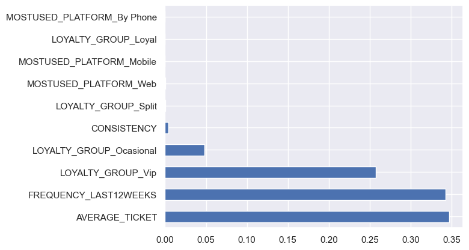

```python
dt_grid_search.best_estimator_.feature_importances_
feat_importances = pd.Series(dt_grid_search.best_estimator_.feature_importances_, index=X_train_preprocessed_data.columns)
feat_importances.nlargest(10).plot(kind='barh')
```

**Reporting Results**

Decision Tree does much better than the other models. We can see that the Adjusted R-squared is much higher and the RMSE and MAE are much lower than the other models.

# **Random Forest**

```python
np.random.seed(1234)
random_forest = RandomForestRegressor(random_state=42)

rf_param_grid = {
    'n_estimators': [50, 100, 200],
    'max_depth': [None, -2, 10, 20],
    'min_samples_split': [5, 10, 15]
}
```

## Cross Validation & Grid Search

```python
rf_grid_search = GridSearchCV(random_forest, rf_param_grid, cv=5, scoring='neg_mean_squared_error', verbose=1)

rf_grid_search.fit(X_train_preprocessed_data, y_train)
```

```
Fitting 5 folds for each of 36 candidates, totalling 180 fits
```

```
GridSearchCV(cv=5, estimator=RandomForestRegressor(random_state=42),
             param_grid={'max_depth': [None, -2, 10, 20],
                         'min_samples_split': [5, 10, 15],
                         'n_estimators': [50, 100, 200]},
             scoring='neg_mean_squared_error', verbose=1)
```

```python
params_rf_grid_search = rf_grid_search.get_params()
print(params_rf_grid_search)
```

```
{'cv': 5, 'error_score': nan, 'estimator__bootstrap': True, 'estimator__ccp_alpha': 0.0, 'estimator__criterion': 'squared_error', 'estimator__max_depth': None, 'estimator__max_features': 1.0, 'estimator__max_leaf_nodes': None, 'estimator__max_samples': None, 'estimator__min_impurity_decrease': 0.0, …
```

```python
# Predictions on the test set
rf_y_pred = rf_grid_search.best_estimator_.predict(X_test_preprocessed_data)

# Calculate RMSE
rf_test_rmse = np.sqrt(mean_squared_error(y_test, rf_y_pred))
print("Random Forest Test RMSE:", rf_test_rmse)

# Calculate MAE
rf_test_mae = mean_absolute_error(y_test, rf_y_pred)
print("Random Forest Test MAE:", rf_test_mae)

# Calculate Adjusted R-squared
rf_r_squared = r2_score(y_test, rf_y_pred)
rf_adjusted_r_squared = 1 - ((1 - rf_r_squared) * (n - 1) / (n - p - 1))
print("Random Forest Test Adjusted R-squared:", rf_adjusted_r_squared)
```

```
Random Forest Test RMSE: 1481.247440692455
Random Forest Test MAE: 160.32695079300453
Random Forest Test Adjusted R-squared: 0.9397608239374277
```

## Feature Importance Random Forest

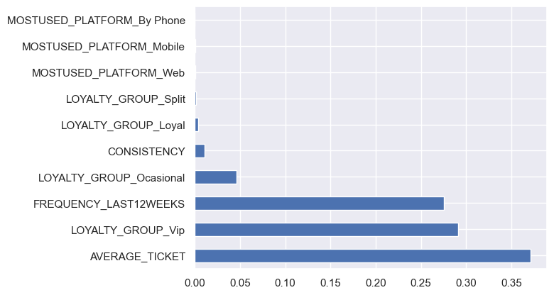

```python
rf_grid_search.best_estimator_.feature_importances_
feat_importances = pd.Series(rf_grid_search.best_estimator_.feature_importances_, index=X_train_preprocessed_data.columns)
feat_importances.nlargest(10).plot(kind='barh')
```

# **Gradient Boosting**

```python
np.random.seed(1234)
gb_model = GradientBoostingRegressor(random_state=42)

gb_model_param_grid = {
    'n_estimators': [50, 250],
    'learning_rate': [0.009, 0.1, 0.4],
    'max_depth': [2, 4, 6]
}
```

## Cross Validation & Grid Search

```python
gb_model_grid_search = GridSearchCV(gb_model, gb_model_param_grid, cv=5, scoring='neg_mean_squared_error', verbose=1)

gb_model_grid_search.fit(X_train_preprocessed_data, y_train)
```

```
Fitting 5 folds for each of 18 candidates, totalling 90 fits
```

```
GridSearchCV(cv=5, estimator=GradientBoostingRegressor(random_state=42),
             param_grid={'learning_rate': [0.009, 0.1, 0.4],
                         'max_depth': [2, 4, 6], 'n_estimators': [50, 250]},
             scoring='neg_mean_squared_error', verbose=1)
```

```python
# Predictions on the test set
gb_model_y_pred = gb_model_grid_search.best_estimator_.predict(X_test_preprocessed_data)

# Calculate RMSE
gb_model_test_rmse = np.sqrt(mean_squared_error(y_test, gb_model_y_pred))
print("GBM Test RMSE:", gb_model_test_rmse)

# Calculate MAE
gb_model_test_mae = mean_absolute_error(y_test, gb_model_y_pred)
print("GBM Test MAE:", gb_model_test_mae)

# Calculate Adjusted R-squared
gb_model_r_squared = r2_score(y_test, gb_model_y_pred)
gb_model_adjusted_r_squared = 1 - ((1 - gb_model_r_squared) * (n - 1) / (n - p - 1))
print("GBM Test Adjusted R-squared:", gb_model_adjusted_r_squared)
```

```
GBM Test RMSE: 989.4004118688001
GBM Test MAE: 168.7927132894338
GBM Test Adjusted R-squared: 0.9731237934100837
```

## Feature Importance GBM

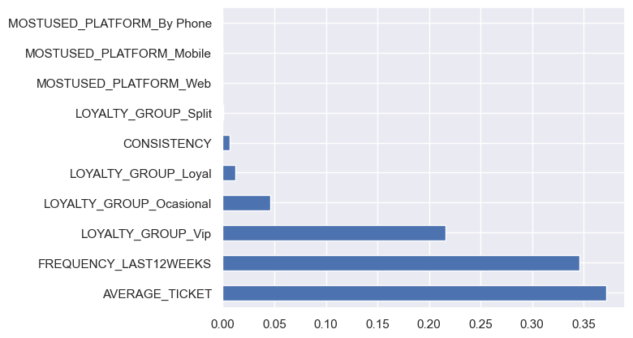

```python
gb_model_grid_search.best_estimator_.feature_importances_
feat_importances = pd.Series(gb_model_grid_search.best_estimator_.feature_importances_, index=X_train_preprocessed_data.columns)
feat_importances.nlargest(10).plot(kind='barh')
```

# **SVR**

```python
np.random.seed(1234)

svr = SVR()

svr_param_grid = {
    'C': [0.1, 1, 10],
    'epsilon': [0.01, 0.1, 0.5],
    'kernel': ['linear', 'rbf', 'poly'],  # Include 'poly' for polynomial kernel
    'degree': [2, 3, 4]  # Example degrees to test for the polynomial kernel
}
```

## Cross Validation & Grid Search

```python
svr_grid_search = GridSearchCV(svr, svr_param_grid, cv=5, scoring='neg_mean_squared_error', verbose=1)

svr_grid_search.fit(X_train_preprocessed_data, y_train)
```

```
Fitting 5 folds for each of 81 candidates, totalling 405 fits
```

```
GridSearchCV(cv=5, estimator=SVR(),
             param_grid={'C': [0.1, 1, 10], 'degree': [2, 3, 4],
                         'epsilon': [0.01, 0.1, 0.5],
                         'kernel': ['linear', 'rbf', 'poly']},
             scoring='neg_mean_squared_error', verbose=1)
```

```python
# Predictions on the test set
svr_y_pred = svr_grid_search.best_estimator_.predict(X_test_preprocessed_data)

# Calculate RMSE, MAE, and Adjusted R-squared as before
svr_test_rmse = np.sqrt(mean_squared_error(y_test, svr_y_pred))
svr_test_mae = mean_absolute_error(y_test, svr_y_pred)
svr_r_squared = r2_score(y_test, svr_y_pred)
svr_adjusted_r_squared = 1 - ((1 - svr_r_squared) * (n - 1) / (n - p - 1))

print("SVR Test RMSE:", svr_test_rmse)
print("SVR Test MAE:", svr_test_mae)
print("SVR Test Adjusted R-squared:", svr_adjusted_r_squared)
```

```
SVR Test RMSE: 3327.3201269086003
SVR Test MAE: 1075.2960075842416
SVR Test Adjusted R-squared: 0.696042424855168
```

```python
from sklearn.inspection import permutation_importance
```

```python
results = permutation_importance(svr_grid_search.best_estimator_, X_test_preprocessed_data, y_test, n_repeats=10, random_state=42)

# Get the importance scores
importances = results.importances_mean
print(importances)
for feature, importances in zip(X_test_preprocessed_data.columns, importances):
    importances_df = pd.DataFrame({'Feature': X_test_preprocessed_data.columns, 'Importances of SVR': importances})
importances_df
```

```
[2.86492183e-01 3.92529124e-01 3.47784057e-01 2.44062357e-02
 5.74917587e-02 1.04760776e-03 1.97636990e-01 4.01919710e-05
 6.71602897e-03 3.79568713e-02]
```

|  | Feature | Importances of SVR |
| --- | --- | --- |
| 0 | FREQUENCY_LAST12WEEKS | 0.038 |
| 1 | AVERAGE_TICKET | 0.038 |
| 2 | CONSISTENCY | 0.038 |
| 3 | LOYALTY_GROUP_Loyal | 0.038 |
| 4 | LOYALTY_GROUP_Ocasional | 0.038 |
| 5 | LOYALTY_GROUP_Split | 0.038 |
| 6 | LOYALTY_GROUP_Vip | 0.038 |
| 7 | MOSTUSED_PLATFORM_By Phone | 0.038 |
| 8 | MOSTUSED_PLATFORM_Mobile | 0.038 |
| 9 | MOSTUSED_PLATFORM_Web | 0.038 |

# Deep Learning Network Model

```python
backend.clear_session()
np.random.seed(42)
import random
random.seed(42)
tf.random.set_seed(42)
```

```python
model_3 = Sequential()

# First hidden layer with 20 neurons and relu activation function, the input shape has 10 independent variables
model_3.add(Dense(20, activation='relu', input_shape=(10,)))

# Output layer with only one neuron and no activation function, as the target variable is numerical.
model_3.add(Dense(1))
```

```python
# Model Compilation
# Specifying the learning rate
learning_rate = 0.001

# Configuring the optimizer with the desired learning rate
optimizer = tf.keras.optimizers.Adam(learning_rate=learning_rate)

model_3.compile(loss='mean_squared_error', optimizer=optimizer, metrics='mean_squared_error')

model_3.summary()
```

```
Model: "sequential"
_________________________________________________________________
 Layer (type)                Output Shape              Param #
=================================================================
 dense (Dense)               (None, 20)                220

 dense_1 (Dense)             (None, 1)                 21

=================================================================
Total params: 241 (964.00 Byte)
Trainable params: 241 (964.00 Byte)
Non-trainable params: 0 (0.00 Byte)
_________________________________________________________________
```

```python
history_3 = model_3.fit(X_train_preprocessed_data, y_train, validation_split=0.1, epochs=300, verbose=1)
```

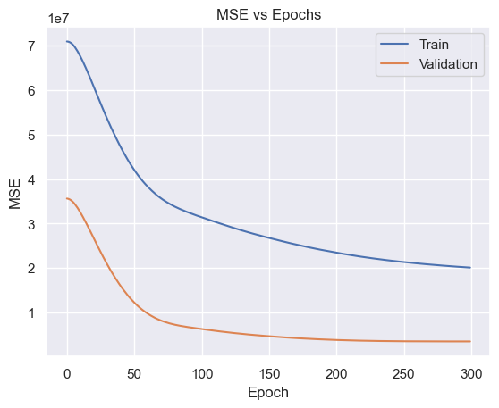

```python
plt.plot(history_3.history['mean_squared_error'])
plt.plot(history_3.history['val_mean_squared_error'])
plt.title('MSE vs Epochs')
plt.ylabel('MSE')
plt.xlabel('Epoch')
plt.legend(['Train', 'Validation'], loc='upper right')
plt.show()
```

```python
nn_y_pred = model_3.predict(X_test_preprocessed_data)
from sklearn.metrics import mean_squared_error
from sklearn.metrics import r2_score
mse = mean_squared_error(y_test, nn_y_pred, squared=True)
print(mse)
```

```
11235472.834457092
```

```python
#Calculate Performace metrics
nn_test_rmse = np.sqrt(mean_squared_error(y_test, nn_y_pred))
nn_test_mae = mean_absolute_error(y_test, nn_y_pred)
n = X_test_preprocessed_data.shape[0]
p = X_test_preprocessed_data.shape[1]
nn_r_squared = r2_score(nn_y_pred, y_test)
nn_adjusted_r_squared = (1 - nn_r_squared) * (n - 1) / (n - p - 1)

print("Neural Network Test RMSE:", nn_test_rmse)
print("Neural Network Test MAE:", nn_test_mae)
print("Neural Network R-Squared:", nn_r_squared)
print("Neural Network Test Adjusted R-Squared:", nn_adjusted_r_squared)
```

```
Neural Network Test RMSE: 3351.9356847136987
Neural Network Test MAE: 1214.7084976478955
Neural Network R-Squared: 0.5251906843655296
Neural Network Test Adjusted R-Squared: 0.47732153423571094
```